# Risk Factor Analysis

## Outcome Variable

**Outcome Variable:** ever_stunted

## Predictor Variables

**Intervention Variable:** impfloor

**Adjustment Set:**

- arm
- sex
- W_mage
- meducyrs
- feducyrs
- hhwealth_quart
- hfoodsec
- W_mhtcm
- W_nrooms
- W_nchldlt5
- W_parity
- impsan
- safeh20
- delta_W_mage
- delta_meducyrs
- delta_feducyrs
- delta_hhwealth_quart
- delta_hfoodsec
- delta_W_mhtcm
- delta_W_nrooms
- delta_W_nchldlt5
- delta_W_parity
- delta_impsan
- delta_safeh20

## Stratifying Variables

The analysis was stratified on these variable(s):

- agecat
- studyid
- country

## Data Summary

| agecat | studyid | country | impfloor | ever_stunted | n_cell | n |
| --- | --- | --- | --- | --- | --- | --- |
| 0-6 months | ki0047075b-MAL-ED | BANGLADESH | 0 | 0 | 17 | 242 |
| 0-6 months | ki0047075b-MAL-ED | BANGLADESH | 0 | 1 | 2 | 242 |
| 0-6 months | ki0047075b-MAL-ED | BANGLADESH | 1 | 0 | 186 | 242 |
| 0-6 months | ki0047075b-MAL-ED | BANGLADESH | 1 | 1 | 37 | 242 |
| 0-6 months | ki0047075b-MAL-ED | BRAZIL | 0 | 0 | 2 | 210 |
| 0-6 months | ki0047075b-MAL-ED | BRAZIL | 0 | 1 | 0 | 210 |
| 0-6 months | ki0047075b-MAL-ED | BRAZIL | 1 | 0 | 187 | 210 |
| 0-6 months | ki0047075b-MAL-ED | BRAZIL | 1 | 1 | 21 | 210 |
| 0-6 months | ki0047075b-MAL-ED | INDIA | 0 | 0 | 14 | 235 |
| 0-6 months | ki0047075b-MAL-ED | INDIA | 0 | 1 | 1 | 235 |
| 0-6 months | ki0047075b-MAL-ED | INDIA | 1 | 0 | 182 | 235 |
| 0-6 months | ki0047075b-MAL-ED | INDIA | 1 | 1 | 38 | 235 |
| 0-6 months | ki0047075b-MAL-ED | NEPAL | 0 | 0 | 117 | 229 |
| 0-6 months | ki0047075b-MAL-ED | NEPAL | 0 | 1 | 9 | 229 |
| 0-6 months | ki0047075b-MAL-ED | NEPAL | 1 | 0 | 86 | 229 |
| 0-6 months | ki0047075b-MAL-ED | NEPAL | 1 | 1 | 17 | 229 |
| 0-6 months | ki0047075b-MAL-ED | PERU | 0 | 0 | 190 | 272 |
| 0-6 months | ki0047075b-MAL-ED | PERU | 0 | 1 | 23 | 272 |
| 0-6 months | ki0047075b-MAL-ED | PERU | 1 | 0 | 48 | 272 |
| 0-6 months | ki0047075b-MAL-ED | PERU | 1 | 1 | 11 | 272 |
| 0-6 months | ki0047075b-MAL-ED | SOUTH AFRICA | 0 | 0 | 20 | 257 |
| 0-6 months | ki0047075b-MAL-ED | SOUTH AFRICA | 0 | 1 | 1 | 257 |
| 0-6 months | ki0047075b-MAL-ED | SOUTH AFRICA | 1 | 0 | 211 | 257 |
| 0-6 months | ki0047075b-MAL-ED | SOUTH AFRICA | 1 | 1 | 25 | 257 |
| 0-6 months | ki0047075b-MAL-ED | TANZANIA, UNITED REPUBLIC OF | 0 | 0 | 198 | 248 |
| 0-6 months | ki0047075b-MAL-ED | TANZANIA, UNITED REPUBLIC OF | 0 | 1 | 36 | 248 |
| 0-6 months | ki0047075b-MAL-ED | TANZANIA, UNITED REPUBLIC OF | 1 | 0 | 11 | 248 |
| 0-6 months | ki0047075b-MAL-ED | TANZANIA, UNITED REPUBLIC OF | 1 | 1 | 3 | 248 |
| 0-6 months | ki1000108-CMC-V-BCS-2002 | INDIA | 1 | 0 | 195 | 257 |
| 0-6 months | ki1000108-CMC-V-BCS-2002 | INDIA | 1 | 1 | 62 | 257 |

[output cut: 150 more lines]

The following strata were considered:

- agecat: 0-24 months, studyid: ki0047075b-MAL-ED, country: BANGLADESH
- agecat: 0-24 months, studyid: ki0047075b-MAL-ED, country: BRAZIL
- agecat: 0-24 months, studyid: ki0047075b-MAL-ED, country: INDIA
- agecat: 0-24 months, studyid: ki0047075b-MAL-ED, country: NEPAL
- agecat: 0-24 months, studyid: ki0047075b-MAL-ED, country: PERU
- agecat: 0-24 months, studyid: ki0047075b-MAL-ED, country: SOUTH AFRICA
- agecat: 0-24 months, studyid: ki0047075b-MAL-ED, country: TANZANIA, UNITED REPUBLIC OF
- agecat: 0-24 months, studyid: ki1000108-CMC-V-BCS-2002, country: INDIA
- agecat: 0-24 months, studyid: ki1000108-IRC, country: INDIA
- agecat: 0-24 months, studyid: ki1017093-NIH-Birth, country: BANGLADESH
- agecat: 0-24 months, studyid: ki1017093b-PROVIDE, country: BANGLADESH
- agecat: 0-24 months, studyid: ki1017093c-NIH-Crypto, country: BANGLADESH
- agecat: 0-24 months, studyid: ki1113344-GMS-Nepal, country: NEPAL
- agecat: 0-24 months, studyid: ki1114097-CONTENT, country: PERU
- agecat: 0-24 months, studyid: kiGH5241-JiVitA-3, country: BANGLADESH
- agecat: 0-24 months, studyid: kiGH5241-JiVitA-4, country: BANGLADESH
- agecat: 0-6 months, studyid: ki0047075b-MAL-ED, country: BANGLADESH
- agecat: 0-6 months, studyid: ki0047075b-MAL-ED, country: BRAZIL
- agecat: 0-6 months, studyid: ki0047075b-MAL-ED, country: INDIA
- agecat: 0-6 months, studyid: ki0047075b-MAL-ED, country: NEPAL
- agecat: 0-6 months, studyid: ki0047075b-MAL-ED, country: PERU
- agecat: 0-6 months, studyid: ki0047075b-MAL-ED, country: SOUTH AFRICA
- agecat: 0-6 months, studyid: ki0047075b-MAL-ED, country: TANZANIA, UNITED REPUBLIC OF
- agecat: 0-6 months, studyid: ki1000108-CMC-V-BCS-2002, country: INDIA
- agecat: 0-6 months, studyid: ki1000108-IRC, country: INDIA
- agecat: 0-6 months, studyid: ki1017093-NIH-Birth, country: BANGLADESH
- agecat: 0-6 months, studyid: ki1017093b-PROVIDE, country: BANGLADESH
- agecat: 0-6 months, studyid: ki1017093c-NIH-Crypto, country: BANGLADESH
- agecat: 0-6 months, studyid: ki1113344-GMS-Nepal, country: NEPAL
- agecat: 0-6 months, studyid: ki1114097-CONTENT, country: PERU
- agecat: 0-6 months, studyid: kiGH5241-JiVitA-3, country: BANGLADESH
- agecat: 0-6 months, studyid: kiGH5241-JiVitA-4, country: BANGLADESH
- agecat: 6-24 months, studyid: ki0047075b-MAL-ED, country: BANGLADESH
- agecat: 6-24 months, studyid: ki0047075b-MAL-ED, country: BRAZIL
- agecat: 6-24 months, studyid: ki0047075b-MAL-ED, country: INDIA
- agecat: 6-24 months, studyid: ki0047075b-MAL-ED, country: NEPAL
- agecat: 6-24 months, studyid: ki0047075b-MAL-ED, country: PERU
- agecat: 6-24 months, studyid: ki0047075b-MAL-ED, country: SOUTH AFRICA
- agecat: 6-24 months, studyid: ki0047075b-MAL-ED, country: TANZANIA, UNITED REPUBLIC OF
- agecat: 6-24 months, studyid: ki1000108-CMC-V-BCS-2002, country: INDIA
- agecat: 6-24 months, studyid: ki1000108-IRC, country: INDIA
- agecat: 6-24 months, studyid: ki1017093-NIH-Birth, country: BANGLADESH
- agecat: 6-24 months, studyid: ki1017093b-PROVIDE, country: BANGLADESH
- agecat: 6-24 months, studyid: ki1017093c-NIH-Crypto, country: BANGLADESH
- agecat: 6-24 months, studyid: ki1113344-GMS-Nepal, country: NEPAL
- agecat: 6-24 months, studyid: ki1114097-CONTENT, country: PERU
- agecat: 6-24 months, studyid: kiGH5241-JiVitA-3, country: BANGLADESH
- agecat: 6-24 months, studyid: kiGH5241-JiVitA-4, country: BANGLADESH

### Dropped Strata

Some strata were dropped due to rare outcomes:

- agecat: 0-6 months, studyid: ki0047075b-MAL-ED, country: BANGLADESH
- agecat: 0-6 months, studyid: ki0047075b-MAL-ED, country: BRAZIL
- agecat: 0-6 months, studyid: ki0047075b-MAL-ED, country: INDIA
- agecat: 0-6 months, studyid: ki0047075b-MAL-ED, country: SOUTH AFRICA
- agecat: 0-6 months, studyid: ki0047075b-MAL-ED, country: TANZANIA, UNITED REPUBLIC OF
- agecat: 0-6 months, studyid: ki1114097-CONTENT, country: PERU
- agecat: 6-24 months, studyid: ki0047075b-MAL-ED, country: BRAZIL
- agecat: 6-24 months, studyid: ki0047075b-MAL-ED, country: INDIA
- agecat: 6-24 months, studyid: ki0047075b-MAL-ED, country: TANZANIA, UNITED REPUBLIC OF
- agecat: 6-24 months, studyid: ki1114097-CONTENT, country: PERU
- agecat: 0-24 months, studyid: ki0047075b-MAL-ED, country: BRAZIL
- agecat: 0-24 months, studyid: ki1114097-CONTENT, country: PERU

## Methods Detail

We’re interested in the causal parameters $E[Y_a]$ for all values of $a \in \mathcal{A}$. These parameters represent the mean outcome if, possibly contrary to fact, we intervened to set all units to have $A=a$. Under the randomization and positivity assumptions, these are identified by the statistical parameters $\psi_a=E_W[E_{Y|A,W}(Y|A=a,W)]$. In addition, we’re interested in the mean of $Y$, $E[Y]$ under no intervention (the observed mean). We will estimate these parameters by using SuperLearner to fit the relevant likelihood factors – $E_{Y|A,W}(Y|A=a,W)$ and $p(A=a|W)$, and then updating our likelihood fit using a joint TMLE.

For unadjusted analyses ($W=\{\}$), initial likelihoods were estimated using Lrnr_glm to estimate the simple $E(Y|A)$ and Lrnr_mean to estimate $p(A)$. For adjusted analyses, a small library containing Lrnr_glmnet, Lrnr_xgboost, and Lrnr_mean was used.

Having estimated these parameters, we will then use the delta method to estimate relative risks and attributable risks relative to a prespecified baseline level of $A$.

[output not shown]

# Results Detail

## Results Plots

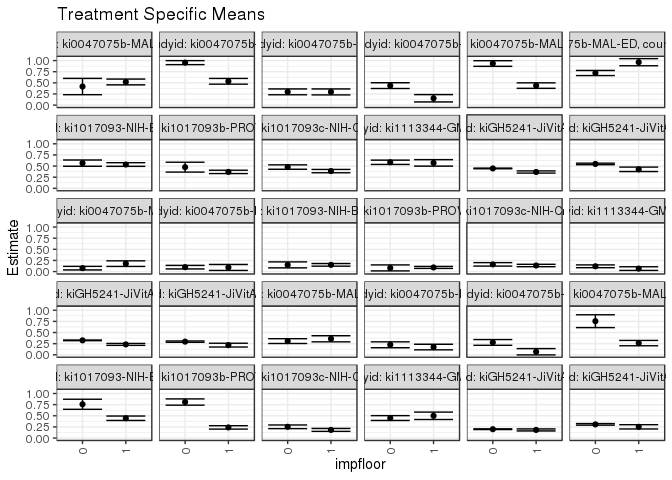

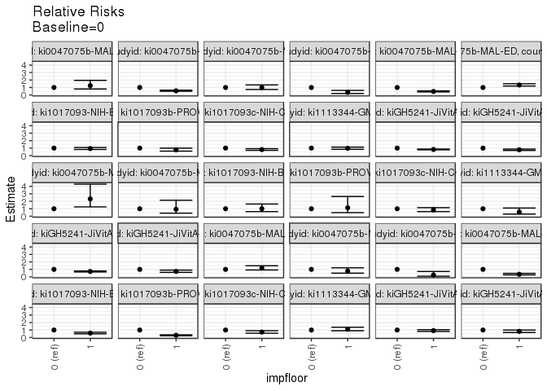

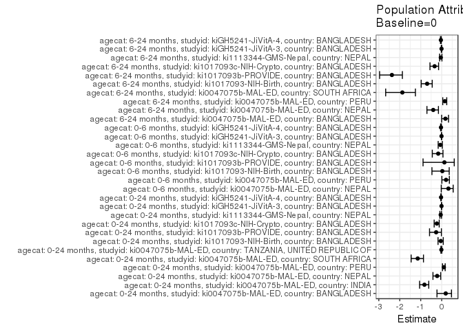

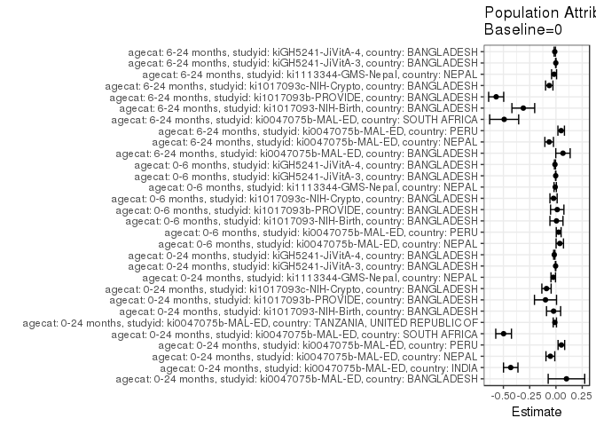

## Results Table

### Parameter: TSM

| agecat | studyid | country | intervention_level | baseline_level | estimate | ci_lower | ci_upper |
| --- | --- | --- | --- | --- | --- | --- | --- |
| 0-24 months | ki0047075b-MAL-ED | BANGLADESH | 0 | NA | 0.4166036 | 0.2338842 | 0.5993231 |
| 0-24 months | ki0047075b-MAL-ED | BANGLADESH | 1 | NA | 0.5195665 | 0.4543784 | 0.5847546 |
| 0-24 months | ki0047075b-MAL-ED | INDIA | 0 | NA | 0.9536775 | 0.9089025 | 0.9984525 |
| 0-24 months | ki0047075b-MAL-ED | INDIA | 1 | NA | 0.5346413 | 0.4700384 | 0.5992442 |
| 0-24 months | ki0047075b-MAL-ED | NEPAL | 0 | NA | 0.2975257 | 0.2320361 | 0.3630154 |
| 0-24 months | ki0047075b-MAL-ED | NEPAL | 1 | NA | 0.2961204 | 0.2289840 | 0.3632569 |
| 0-24 months | ki0047075b-MAL-ED | PERU | 0 | NA | 0.4374929 | 0.3726274 | 0.5023584 |
| 0-24 months | ki0047075b-MAL-ED | PERU | 1 | NA | 0.1536997 | 0.0714190 | 0.2359804 |
| 0-24 months | ki0047075b-MAL-ED | SOUTH AFRICA | 0 | NA | 0.9337561 | 0.8702095 | 0.9973026 |
| 0-24 months | ki0047075b-MAL-ED | SOUTH AFRICA | 1 | NA | 0.4381035 | 0.3763328 | 0.4998741 |
| 0-24 months | ki0047075b-MAL-ED | TANZANIA, UNITED REPUBLIC OF | 0 | NA | 0.7202605 | 0.6630190 | 0.7775021 |
| 0-24 months | ki0047075b-MAL-ED | TANZANIA, UNITED REPUBLIC OF | 1 | NA | 0.9632317 | 0.8831871 | 1.0432763 |
| 0-24 months | ki1017093-NIH-Birth | BANGLADESH | 0 | NA | 0.5657470 | 0.4953066 | 0.6361873 |
| 0-24 months | ki1017093-NIH-Birth | BANGLADESH | 1 | NA | 0.5349072 | 0.4939303 | 0.5758840 |
| 0-24 months | ki1017093b-PROVIDE | BANGLADESH | 0 | NA | 0.4751362 | 0.3640943 | 0.5861781 |
| 0-24 months | ki1017093b-PROVIDE | BANGLADESH | 1 | NA | 0.3688304 | 0.3316380 | 0.4060228 |
| 0-24 months | ki1017093c-NIH-Crypto | BANGLADESH | 0 | NA | 0.4778145 | 0.4281041 | 0.5275248 |
| 0-24 months | ki1017093c-NIH-Crypto | BANGLADESH | 1 | NA | 0.3868948 | 0.3493109 | 0.4244787 |
| 0-24 months | ki1113344-GMS-Nepal | NEPAL | 0 | NA | 0.5848685 | 0.5367565 | 0.6329805 |
| 0-24 months | ki1113344-GMS-Nepal | NEPAL | 1 | NA | 0.5712306 | 0.4985584 | 0.6439028 |
| 0-24 months | kiGH5241-JiVitA-3 | BANGLADESH | 0 | NA | 0.4471513 | 0.4394338 | 0.4548688 |
| 0-24 months | kiGH5241-JiVitA-3 | BANGLADESH | 1 | NA | 0.3669751 | 0.3423244 | 0.3916259 |
| 0-24 months | kiGH5241-JiVitA-4 | BANGLADESH | 0 | NA | 0.5481175 | 0.5310538 | 0.5651811 |
| 0-24 months | kiGH5241-JiVitA-4 | BANGLADESH | 1 | NA | 0.4271285 | 0.3772716 | 0.4769854 |
| 0-6 months | ki0047075b-MAL-ED | NEPAL | 0 | NA | 0.0769715 | 0.0368156 | 0.1171274 |
| 0-6 months | ki0047075b-MAL-ED | NEPAL | 1 | NA | 0.1781386 | 0.1152143 | 0.2410628 |
| 0-6 months | ki0047075b-MAL-ED | PERU | 0 | NA | 0.0989356 | 0.0592109 | 0.1386603 |
| 0-6 months | ki0047075b-MAL-ED | PERU | 1 | NA | 0.0924649 | 0.0253107 | 0.1596190 |
| 0-6 months | ki1017093-NIH-Birth | BANGLADESH | 0 | NA | 0.1500523 | 0.0833404 | 0.2167641 |
| 0-6 months | ki1017093-NIH-Birth | BANGLADESH | 1 | NA | 0.1509647 | 0.1213285 | 0.1806009 |
| 0-6 months | ki1017093b-PROVIDE | BANGLADESH | 0 | NA | 0.0820178 | 0.0146787 | 0.1493569 |
| 0-6 months | ki1017093b-PROVIDE | BANGLADESH | 1 | NA | 0.0926278 | 0.0702562 | 0.1149993 |
| 0-6 months | ki1017093c-NIH-Crypto | BANGLADESH | 0 | NA | 0.1614079 | 0.1224614 | 0.2003543 |
| 0-6 months | ki1017093c-NIH-Crypto | BANGLADESH | 1 | NA | 0.1365385 | 0.1096671 | 0.1634100 |
| 0-6 months | ki1113344-GMS-Nepal | NEPAL | 0 | NA | 0.1188588 | 0.0874442 | 0.1502733 |
| 0-6 months | ki1113344-GMS-Nepal | NEPAL | 1 | NA | 0.0669582 | 0.0258232 | 0.1080933 |
| 0-6 months | kiGH5241-JiVitA-3 | BANGLADESH | 0 | NA | 0.3245448 | 0.3175427 | 0.3315470 |
| 0-6 months | kiGH5241-JiVitA-3 | BANGLADESH | 1 | NA | 0.2333364 | 0.2117051 | 0.2549677 |
| 0-6 months | kiGH5241-JiVitA-4 | BANGLADESH | 0 | NA | 0.2958990 | 0.2810859 | 0.3107122 |
| 0-6 months | kiGH5241-JiVitA-4 | BANGLADESH | 1 | NA | 0.2171075 | 0.1740324 | 0.2601827 |
| 6-24 months | ki0047075b-MAL-ED | BANGLADESH | 0 | NA | 0.3075362 | 0.2538838 | 0.3611885 |
| 6-24 months | ki0047075b-MAL-ED | BANGLADESH | 1 | NA | 0.3597724 | 0.2914734 | 0.4280715 |
| 6-24 months | ki0047075b-MAL-ED | NEPAL | 0 | NA | 0.2251473 | 0.1587087 | 0.2915859 |
| 6-24 months | ki0047075b-MAL-ED | NEPAL | 1 | NA | 0.1743488 | 0.1119494 | 0.2367482 |
| 6-24 months | ki0047075b-MAL-ED | PERU | 0 | NA | 0.2778253 | 0.2134259 | 0.3422246 |
| 6-24 months | ki0047075b-MAL-ED | PERU | 1 | NA | 0.0685334 | -0.0022204 | 0.1392873 |
| 6-24 months | ki0047075b-MAL-ED | SOUTH AFRICA | 0 | NA | 0.7549907 | 0.6108784 | 0.8991029 |
| 6-24 months | ki0047075b-MAL-ED | SOUTH AFRICA | 1 | NA | 0.2626443 | 0.2027134 | 0.3225751 |
| 6-24 months | ki1017093-NIH-Birth | BANGLADESH | 0 | NA | 0.7579989 | 0.6454436 | 0.8705542 |
| 6-24 months | ki1017093-NIH-Birth | BANGLADESH | 1 | NA | 0.4441026 | 0.3945479 | 0.4936573 |
| 6-24 months | ki1017093b-PROVIDE | BANGLADESH | 0 | NA | 0.8082081 | 0.7376120 | 0.8788041 |
| 6-24 months | ki1017093b-PROVIDE | BANGLADESH | 1 | NA | 0.2383766 | 0.2001374 | 0.2766159 |
| 6-24 months | ki1017093c-NIH-Crypto | BANGLADESH | 0 | NA | 0.2523047 | 0.2112413 | 0.2933680 |
| 6-24 months | ki1017093c-NIH-Crypto | BANGLADESH | 1 | NA | 0.1823552 | 0.1498011 | 0.2149093 |
| 6-24 months | ki1113344-GMS-Nepal | NEPAL | 0 | NA | 0.4485975 | 0.3944039 | 0.5027910 |
| 6-24 months | ki1113344-GMS-Nepal | NEPAL | 1 | NA | 0.4989738 | 0.4158526 | 0.5820950 |
| 6-24 months | kiGH5241-JiVitA-3 | BANGLADESH | 0 | NA | 0.1981419 | 0.1897049 | 0.2065790 |
| 6-24 months | kiGH5241-JiVitA-3 | BANGLADESH | 1 | NA | 0.1818158 | 0.1594540 | 0.2041775 |
| 6-24 months | kiGH5241-JiVitA-4 | BANGLADESH | 0 | NA | 0.3065102 | 0.2890356 | 0.3239849 |
| 6-24 months | kiGH5241-JiVitA-4 | BANGLADESH | 1 | NA | 0.2514280 | 0.2038854 | 0.2989706 |

### Parameter: E(Y)

| agecat | studyid | country | intervention_level | baseline_level | estimate | ci_lower | ci_upper |
| --- | --- | --- | --- | --- | --- | --- | --- |
| 0-24 months | ki0047075b-MAL-ED | BANGLADESH | NA | NA | 0.5165289 | 0.4534372 | 0.5796206 |
| 0-24 months | ki0047075b-MAL-ED | INDIA | NA | NA | 0.5234043 | 0.4594110 | 0.5873975 |
| 0-24 months | ki0047075b-MAL-ED | NEPAL | NA | NA | 0.2445415 | 0.1887507 | 0.3003322 |
| 0-24 months | ki0047075b-MAL-ED | PERU | NA | NA | 0.4889706 | 0.4294554 | 0.5484858 |
| 0-24 months | ki0047075b-MAL-ED | SOUTH AFRICA | NA | NA | 0.4357977 | 0.3750558 | 0.4965395 |
| 0-24 months | ki0047075b-MAL-ED | TANZANIA, UNITED REPUBLIC OF | NA | NA | 0.7096774 | 0.6530704 | 0.7662845 |
| 0-24 months | ki1017093-NIH-Birth | BANGLADESH | NA | NA | 0.5431310 | 0.5040778 | 0.5821842 |
| 0-24 months | ki1017093b-PROVIDE | BANGLADESH | NA | NA | 0.3757143 | 0.3398113 | 0.4116172 |
| 0-24 months | ki1017093c-NIH-Crypto | BANGLADESH | NA | NA | 0.3878628 | 0.3531521 | 0.4225735 |
| 0-24 months | ki1113344-GMS-Nepal | NEPAL | NA | NA | 0.5590717 | 0.5143277 | 0.6038158 |
| 0-24 months | kiGH5241-JiVitA-3 | BANGLADESH | NA | NA | 0.4437900 | 0.4362765 | 0.4513035 |
| 0-24 months | kiGH5241-JiVitA-4 | BANGLADESH | NA | NA | 0.5321659 | 0.5159814 | 0.5483504 |
| 0-6 months | ki0047075b-MAL-ED | NEPAL | NA | NA | 0.1135371 | 0.0723577 | 0.1547165 |
| 0-6 months | ki0047075b-MAL-ED | PERU | NA | NA | 0.1250000 | 0.0856248 | 0.1643752 |
| 0-6 months | ki1017093-NIH-Birth | BANGLADESH | NA | NA | 0.1549521 | 0.1265829 | 0.1833213 |
| 0-6 months | ki1017093b-PROVIDE | BANGLADESH | NA | NA | 0.0942857 | 0.0726222 | 0.1159492 |
| 0-6 months | ki1017093c-NIH-Crypto | BANGLADESH | NA | NA | 0.1385224 | 0.1139141 | 0.1631308 |
| 0-6 months | ki1113344-GMS-Nepal | NEPAL | NA | NA | 0.1118143 | 0.0834144 | 0.1402143 |
| 0-6 months | kiGH5241-JiVitA-3 | BANGLADESH | NA | NA | 0.3220295 | 0.3152463 | 0.3288127 |
| 0-6 months | kiGH5241-JiVitA-4 | BANGLADESH | NA | NA | 0.2864960 | 0.2726657 | 0.3003263 |
| 6-24 months | ki0047075b-MAL-ED | BANGLADESH | NA | NA | 0.3743590 | 0.3062579 | 0.4424600 |
| 6-24 months | ki0047075b-MAL-ED | NEPAL | NA | NA | 0.1605505 | 0.1117053 | 0.2093956 |
| 6-24 months | ki0047075b-MAL-ED | PERU | NA | NA | 0.3275109 | 0.2665942 | 0.3884276 |
| 6-24 months | ki0047075b-MAL-ED | SOUTH AFRICA | NA | NA | 0.2624434 | 0.2043065 | 0.3205804 |
| 6-24 months | ki1017093-NIH-Birth | BANGLADESH | NA | NA | 0.4473684 | 0.3996451 | 0.4950917 |
| 6-24 months | ki1017093b-PROVIDE | BANGLADESH | NA | NA | 0.2394366 | 0.2018814 | 0.2769918 |
| 6-24 months | ki1017093c-NIH-Crypto | BANGLADESH | NA | NA | 0.1887097 | 0.1578857 | 0.2195336 |
| 6-24 months | ki1113344-GMS-Nepal | NEPAL | NA | NA | 0.4308094 | 0.3811516 | 0.4804672 |
| 6-24 months | kiGH5241-JiVitA-3 | BANGLADESH | NA | NA | 0.1966855 | 0.1886595 | 0.2047115 |
| 6-24 months | kiGH5241-JiVitA-4 | BANGLADESH | NA | NA | 0.2952381 | 0.2788899 | 0.3115863 |

### Parameter: RR

| agecat | studyid | country | intervention_level | baseline_level | estimate | ci_lower | ci_upper |
| --- | --- | --- | --- | --- | --- | --- | --- |
| 0-24 months | ki0047075b-MAL-ED | BANGLADESH | 0 | 0 | 1.0000000 | 1.0000000 | 1.0000000 |
| 0-24 months | ki0047075b-MAL-ED | BANGLADESH | 1 | 0 | 1.2471482 | 0.7969240 | 1.9517276 |
| 0-24 months | ki0047075b-MAL-ED | INDIA | 0 | 0 | 1.0000000 | 1.0000000 | 1.0000000 |
| 0-24 months | ki0047075b-MAL-ED | INDIA | 1 | 0 | 0.5606102 | 0.4923911 | 0.6382808 |
| 0-24 months | ki0047075b-MAL-ED | NEPAL | 0 | 0 | 1.0000000 | 1.0000000 | 1.0000000 |
| 0-24 months | ki0047075b-MAL-ED | NEPAL | 1 | 0 | 0.9952767 | 0.7369847 | 1.3440926 |
| 0-24 months | ki0047075b-MAL-ED | PERU | 0 | 0 | 1.0000000 | 1.0000000 | 1.0000000 |
| 0-24 months | ki0047075b-MAL-ED | PERU | 1 | 0 | 0.3513194 | 0.2011425 | 0.6136214 |
| 0-24 months | ki0047075b-MAL-ED | SOUTH AFRICA | 0 | 0 | 1.0000000 | 1.0000000 | 1.0000000 |
| 0-24 months | ki0047075b-MAL-ED | SOUTH AFRICA | 1 | 0 | 0.4691841 | 0.4032096 | 0.5459535 |
| 0-24 months | ki0047075b-MAL-ED | TANZANIA, UNITED REPUBLIC OF | 0 | 0 | 1.0000000 | 1.0000000 | 1.0000000 |
| 0-24 months | ki0047075b-MAL-ED | TANZANIA, UNITED REPUBLIC OF | 1 | 0 | 1.3373379 | 1.1920223 | 1.5003684 |
| 0-24 months | ki1017093-NIH-Birth | BANGLADESH | 0 | 0 | 1.0000000 | 1.0000000 | 1.0000000 |
| 0-24 months | ki1017093-NIH-Birth | BANGLADESH | 1 | 0 | 0.9454883 | 0.8201446 | 1.0899886 |
| 0-24 months | ki1017093b-PROVIDE | BANGLADESH | 0 | 0 | 1.0000000 | 1.0000000 | 1.0000000 |
| 0-24 months | ki1017093b-PROVIDE | BANGLADESH | 1 | 0 | 0.7762624 | 0.6037740 | 0.9980280 |
| 0-24 months | ki1017093c-NIH-Crypto | BANGLADESH | 0 | 0 | 1.0000000 | 1.0000000 | 1.0000000 |
| 0-24 months | ki1017093c-NIH-Crypto | BANGLADESH | 1 | 0 | 0.8097175 | 0.7047529 | 0.9303154 |
| 0-24 months | ki1113344-GMS-Nepal | NEPAL | 0 | 0 | 1.0000000 | 1.0000000 | 1.0000000 |
| 0-24 months | ki1113344-GMS-Nepal | NEPAL | 1 | 0 | 0.9766821 | 0.8392977 | 1.1365550 |
| 0-24 months | kiGH5241-JiVitA-3 | BANGLADESH | 0 | 0 | 1.0000000 | 1.0000000 | 1.0000000 |
| 0-24 months | kiGH5241-JiVitA-3 | BANGLADESH | 1 | 0 | 0.8206957 | 0.7662380 | 0.8790239 |
| 0-24 months | kiGH5241-JiVitA-4 | BANGLADESH | 0 | 0 | 1.0000000 | 1.0000000 | 1.0000000 |
| 0-24 months | kiGH5241-JiVitA-4 | BANGLADESH | 1 | 0 | 0.7792645 | 0.6917464 | 0.8778553 |
| 0-6 months | ki0047075b-MAL-ED | NEPAL | 0 | 0 | 1.0000000 | 1.0000000 | 1.0000000 |
| 0-6 months | ki0047075b-MAL-ED | NEPAL | 1 | 0 | 2.3143435 | 1.2496989 | 4.2859811 |
| 0-6 months | ki0047075b-MAL-ED | PERU | 0 | 0 | 1.0000000 | 1.0000000 | 1.0000000 |
| 0-6 months | ki0047075b-MAL-ED | PERU | 1 | 0 | 0.9345966 | 0.4091013 | 2.1350971 |
| 0-6 months | ki1017093-NIH-Birth | BANGLADESH | 0 | 0 | 1.0000000 | 1.0000000 | 1.0000000 |
| 0-6 months | ki1017093-NIH-Birth | BANGLADESH | 1 | 0 | 1.0060807 | 0.6194553 | 1.6340135 |
| 0-6 months | ki1017093b-PROVIDE | BANGLADESH | 0 | 0 | 1.0000000 | 1.0000000 | 1.0000000 |
| 0-6 months | ki1017093b-PROVIDE | BANGLADESH | 1 | 0 | 1.1293616 | 0.4829892 | 2.6407581 |
| 0-6 months | ki1017093c-NIH-Crypto | BANGLADESH | 0 | 0 | 1.0000000 | 1.0000000 | 1.0000000 |
| 0-6 months | ki1017093c-NIH-Crypto | BANGLADESH | 1 | 0 | 0.8459225 | 0.6212571 | 1.1518337 |
| 0-6 months | ki1113344-GMS-Nepal | NEPAL | 0 | 0 | 1.0000000 | 1.0000000 | 1.0000000 |
| 0-6 months | ki1113344-GMS-Nepal | NEPAL | 1 | 0 | 0.5633428 | 0.2886820 | 1.0993241 |
| 0-6 months | kiGH5241-JiVitA-3 | BANGLADESH | 0 | 0 | 1.0000000 | 1.0000000 | 1.0000000 |
| 0-6 months | kiGH5241-JiVitA-3 | BANGLADESH | 1 | 0 | 0.7189650 | 0.6537169 | 0.7907256 |
| 0-6 months | kiGH5241-JiVitA-4 | BANGLADESH | 0 | 0 | 1.0000000 | 1.0000000 | 1.0000000 |
| 0-6 months | kiGH5241-JiVitA-4 | BANGLADESH | 1 | 0 | 0.7337217 | 0.5993041 | 0.8982878 |
| 6-24 months | ki0047075b-MAL-ED | BANGLADESH | 0 | 0 | 1.0000000 | 1.0000000 | 1.0000000 |
| 6-24 months | ki0047075b-MAL-ED | BANGLADESH | 1 | 0 | 1.1698541 | 0.9195295 | 1.4883249 |
| 6-24 months | ki0047075b-MAL-ED | NEPAL | 0 | 0 | 1.0000000 | 1.0000000 | 1.0000000 |
| 6-24 months | ki0047075b-MAL-ED | NEPAL | 1 | 0 | 0.7743765 | 0.4961180 | 1.2087022 |
| 6-24 months | ki0047075b-MAL-ED | PERU | 0 | 0 | 1.0000000 | 1.0000000 | 1.0000000 |
| 6-24 months | ki0047075b-MAL-ED | PERU | 1 | 0 | 0.2466782 | 0.0848005 | 0.7175680 |
| 6-24 months | ki0047075b-MAL-ED | SOUTH AFRICA | 0 | 0 | 1.0000000 | 1.0000000 | 1.0000000 |
| 6-24 months | ki0047075b-MAL-ED | SOUTH AFRICA | 1 | 0 | 0.3478775 | 0.2589598 | 0.4673264 |
| 6-24 months | ki1017093-NIH-Birth | BANGLADESH | 0 | 0 | 1.0000000 | 1.0000000 | 1.0000000 |
| 6-24 months | ki1017093-NIH-Birth | BANGLADESH | 1 | 0 | 0.5858882 | 0.4878183 | 0.7036738 |
| 6-24 months | ki1017093b-PROVIDE | BANGLADESH | 0 | 0 | 1.0000000 | 1.0000000 | 1.0000000 |
| 6-24 months | ki1017093b-PROVIDE | BANGLADESH | 1 | 0 | 0.2949446 | 0.2459380 | 0.3537165 |
| 6-24 months | ki1017093c-NIH-Crypto | BANGLADESH | 0 | 0 | 1.0000000 | 1.0000000 | 1.0000000 |
| 6-24 months | ki1017093c-NIH-Crypto | BANGLADESH | 1 | 0 | 0.7227578 | 0.5748703 | 0.9086900 |
| 6-24 months | ki1113344-GMS-Nepal | NEPAL | 0 | 0 | 1.0000000 | 1.0000000 | 1.0000000 |
| 6-24 months | ki1113344-GMS-Nepal | NEPAL | 1 | 0 | 1.1122974 | 0.9056752 | 1.3660587 |
| 6-24 months | kiGH5241-JiVitA-3 | BANGLADESH | 0 | 0 | 1.0000000 | 1.0000000 | 1.0000000 |
| 6-24 months | kiGH5241-JiVitA-3 | BANGLADESH | 1 | 0 | 0.9176036 | 0.8051073 | 1.0458190 |
| 6-24 months | kiGH5241-JiVitA-4 | BANGLADESH | 0 | 0 | 1.0000000 | 1.0000000 | 1.0000000 |
| 6-24 months | kiGH5241-JiVitA-4 | BANGLADESH | 1 | 0 | 0.8202923 | 0.6739496 | 0.9984122 |

### Parameter: PAR

| agecat | studyid | country | intervention_level | baseline_level | estimate | ci_lower | ci_upper |
| --- | --- | --- | --- | --- | --- | --- | --- |
| 0-24 months | ki0047075b-MAL-ED | BANGLADESH | 0 | NA | 0.0999253 | -0.0738266 | 0.2736771 |
| 0-24 months | ki0047075b-MAL-ED | INDIA | 0 | NA | -0.4302733 | -0.4990156 | -0.3615309 |
| 0-24 months | ki0047075b-MAL-ED | NEPAL | 0 | NA | -0.0529843 | -0.0949802 | -0.0109884 |
| 0-24 months | ki0047075b-MAL-ED | PERU | 0 | NA | 0.0514777 | 0.0200394 | 0.0829161 |
| 0-24 months | ki0047075b-MAL-ED | SOUTH AFRICA | 0 | NA | -0.4979584 | -0.5726276 | -0.4232892 |
| 0-24 months | ki0047075b-MAL-ED | TANZANIA, UNITED REPUBLIC OF | 0 | NA | -0.0105831 | -0.0262098 | 0.0050436 |
| 0-24 months | ki1017093-NIH-Birth | BANGLADESH | 0 | NA | -0.0226160 | -0.0898249 | 0.0445930 |
| 0-24 months | ki1017093b-PROVIDE | BANGLADESH | 0 | NA | -0.0994219 | -0.2044216 | 0.0055778 |
| 0-24 months | ki1017093c-NIH-Crypto | BANGLADESH | 0 | NA | -0.0899517 | -0.1341243 | -0.0457791 |
| 0-24 months | ki1113344-GMS-Nepal | NEPAL | 0 | NA | -0.0257968 | -0.0474368 | -0.0041567 |
| 0-24 months | kiGH5241-JiVitA-3 | BANGLADESH | 0 | NA | -0.0033612 | -0.0051836 | -0.0015389 |
| 0-24 months | kiGH5241-JiVitA-4 | BANGLADESH | 0 | NA | -0.0159516 | -0.0219596 | -0.0099436 |
| 0-6 months | ki0047075b-MAL-ED | NEPAL | 0 | NA | 0.0365656 | 0.0013989 | 0.0717323 |
| 0-6 months | ki0047075b-MAL-ED | PERU | 0 | NA | 0.0260644 | 0.0030843 | 0.0490446 |
| 0-6 months | ki1017093-NIH-Birth | BANGLADESH | 0 | NA | 0.0048998 | -0.0571827 | 0.0669823 |
| 0-6 months | ki1017093b-PROVIDE | BANGLADESH | 0 | NA | 0.0122679 | -0.0512201 | 0.0757559 |
| 0-6 months | ki1017093c-NIH-Crypto | BANGLADESH | 0 | NA | -0.0228854 | -0.0570632 | 0.0112924 |
| 0-6 months | ki1113344-GMS-Nepal | NEPAL | 0 | NA | -0.0070444 | -0.0181247 | 0.0040358 |
| 0-6 months | kiGH5241-JiVitA-3 | BANGLADESH | 0 | NA | -0.0025153 | -0.0041971 | -0.0008335 |
| 0-6 months | kiGH5241-JiVitA-4 | BANGLADESH | 0 | NA | -0.0094030 | -0.0145369 | -0.0042692 |
| 6-24 months | ki0047075b-MAL-ED | BANGLADESH | 0 | NA | 0.0668228 | -0.0016190 | 0.1352646 |
| 6-24 months | ki0047075b-MAL-ED | NEPAL | 0 | NA | -0.0645968 | -0.1055116 | -0.0236820 |
| 6-24 months | ki0047075b-MAL-ED | PERU | 0 | NA | 0.0496857 | 0.0186062 | 0.0807652 |
| 6-24 months | ki0047075b-MAL-ED | SOUTH AFRICA | 0 | NA | -0.4925472 | -0.6304489 | -0.3546455 |
| 6-24 months | ki1017093-NIH-Birth | BANGLADESH | 0 | NA | -0.3106305 | -0.4189476 | -0.2023134 |
| 6-24 months | ki1017093b-PROVIDE | BANGLADESH | 0 | NA | -0.5687715 | -0.6404065 | -0.4971364 |
| 6-24 months | ki1017093c-NIH-Crypto | BANGLADESH | 0 | NA | -0.0635950 | -0.0985410 | -0.0286491 |
| 6-24 months | ki1113344-GMS-Nepal | NEPAL | 0 | NA | -0.0177881 | -0.0415915 | 0.0060153 |
| 6-24 months | kiGH5241-JiVitA-3 | BANGLADESH | 0 | NA | -0.0014564 | -0.0036837 | 0.0007709 |
| 6-24 months | kiGH5241-JiVitA-4 | BANGLADESH | 0 | NA | -0.0112722 | -0.0171901 | -0.0053542 |

### Parameter: PAF

| agecat | studyid | country | intervention_level | baseline_level | estimate | ci_lower | ci_upper |
| --- | --- | --- | --- | --- | --- | --- | --- |
| 0-24 months | ki0047075b-MAL-ED | BANGLADESH | 0 | NA | 0.1934553 | -0.2239130 | 0.4684963 |
| 0-24 months | ki0047075b-MAL-ED | INDIA | 0 | NA | -0.8220668 | -1.0543675 | -0.6160339 |
| 0-24 months | ki0047075b-MAL-ED | NEPAL | 0 | NA | -0.2166678 | -0.4159663 | -0.0454207 |
| 0-24 months | ki0047075b-MAL-ED | PERU | 0 | NA | 0.1052778 | 0.0384326 | 0.1674761 |
| 0-24 months | ki0047075b-MAL-ED | SOUTH AFRICA | 0 | NA | -1.1426367 | -1.4572403 | -0.8683122 |
| 0-24 months | ki0047075b-MAL-ED | TANZANIA, UNITED REPUBLIC OF | 0 | NA | -0.0149126 | -0.0373231 | 0.0070139 |
| 0-24 months | ki1017093-NIH-Birth | BANGLADESH | 0 | NA | -0.0416400 | -0.1737667 | 0.0756137 |
| 0-24 months | ki1017093b-PROVIDE | BANGLADESH | 0 | NA | -0.2646211 | -0.5787302 | -0.0130081 |
| 0-24 months | ki1017093c-NIH-Crypto | BANGLADESH | 0 | NA | -0.2319163 | -0.3582165 | -0.1173606 |
| 0-24 months | ki1113344-GMS-Nepal | NEPAL | 0 | NA | -0.0461422 | -0.0860621 | -0.0076896 |
| 0-24 months | kiGH5241-JiVitA-3 | BANGLADESH | 0 | NA | -0.0075739 | -0.0116917 | -0.0034730 |
| 0-24 months | kiGH5241-JiVitA-4 | BANGLADESH | 0 | NA | -0.0299748 | -0.0413961 | -0.0186787 |
| 0-6 months | ki0047075b-MAL-ED | NEPAL | 0 | NA | 0.3220584 | -0.0197564 | 0.5492994 |
| 0-6 months | ki0047075b-MAL-ED | PERU | 0 | NA | 0.2085153 | 0.0097937 | 0.3673561 |
| 0-6 months | ki1017093-NIH-Birth | BANGLADESH | 0 | NA | 0.0316214 | -0.4641809 | 0.3595346 |
| 0-6 months | ki1017093b-PROVIDE | BANGLADESH | 0 | NA | 0.1301139 | -0.8886751 | 0.5993478 |
| 0-6 months | ki1017093c-NIH-Crypto | BANGLADESH | 0 | NA | -0.1652111 | -0.4476318 | 0.0621117 |
| 0-6 months | ki1113344-GMS-Nepal | NEPAL | 0 | NA | -0.0630012 | -0.1666741 | 0.0314591 |
| 0-6 months | kiGH5241-JiVitA-3 | BANGLADESH | 0 | NA | -0.0078108 | -0.0130481 | -0.0026006 |
| 0-6 months | kiGH5241-JiVitA-4 | BANGLADESH | 0 | NA | -0.0328209 | -0.0509476 | -0.0150068 |
| 6-24 months | ki0047075b-MAL-ED | BANGLADESH | 0 | NA | 0.1784993 | -0.0006835 | 0.3255975 |
| 6-24 months | ki0047075b-MAL-ED | NEPAL | 0 | NA | -0.4023459 | -0.7034402 | -0.1544721 |
| 6-24 months | ki0047075b-MAL-ED | PERU | 0 | NA | 0.1517069 | 0.0510209 | 0.2417102 |
| 6-24 months | ki0047075b-MAL-ED | SOUTH AFRICA | 0 | NA | -1.8767747 | -2.6723086 | -1.2535778 |
| 6-24 months | ki1017093-NIH-Birth | BANGLADESH | 0 | NA | -0.6943505 | -0.9779571 | -0.4514085 |
| 6-24 months | ki1017093b-PROVIDE | BANGLADESH | 0 | NA | -2.3754573 | -2.9624537 | -1.8754183 |
| 6-24 months | ki1017093c-NIH-Crypto | BANGLADESH | 0 | NA | -0.3369992 | -0.5582346 | -0.1471744 |
| 6-24 months | ki1113344-GMS-Nepal | NEPAL | 0 | NA | -0.0412899 | -0.0984524 | 0.0128979 |
| 6-24 months | kiGH5241-JiVitA-3 | BANGLADESH | 0 | NA | -0.0074049 | -0.0187816 | 0.0038447 |
| 6-24 months | kiGH5241-JiVitA-4 | BANGLADESH | 0 | NA | -0.0381799 | -0.0584986 | -0.0182511 |